# Analysis of Real Estate Market

Ralitza Mondal & Cuicui Lu

# 1 Clear the environment and load packages

```r
# Clear environment of variables and functions
rm(list = ls(all = TRUE))

# Clear environmet of packages
if(is.null(sessionInfo()$otherPkgs) == FALSE)lapply(paste("package:", names(sessionInfo()$otherPkgs), sep=""), detach, character.only = TRUE, unload = TRUE)
```

```r
library(tidyverse)
library(scales)
library(gridExtra)
library(janitor)
library(knitr)
library(GGally)
```

# 2 Load the data

```r
# Assignment: 5210 Data Visualization-PA1
# Purpose: Orange juice sale based on uni-variate non-graphical analysis
# Date: 9/26/2019
```

Load the qp1_data.csv data into df

```r
df<-read.csv('qp1_data.csv')
```

# 3 Base EDA Step 1: Univariate non-graphical EDA

Check the data type

```r
str(df)
```

```
## 'data.frame':    21613 obs. of  13 variables:
##  $ price       : num  221900 538000 180000 604000 510000 ...
##  $ bedrooms    : int  3 3 2 4 3 4 3 3 3 3 ...
##  $ bathrooms   : num  1 2.25 1 3 2 4.5 2.25 1.5 1 2.5 ...
##  $ sqft_living : int  1180 2570 770 1960 1680 5420 1715 1060 1780 1890 ...
##  $ sqft_lot    : int  5650 7242 10000 5000 8080 101930 6819 9711 7470 6560 ...
##  $ floors      : num  1 2 1 1 1 1 2 1 1 2 ...
##  $ waterfront  : int  0 0 0 0 0 0 0 0 0 0 ...
##  $ view        : int  0 0 0 0 0 0 0 0 0 0 ...
##  $ grade       : int  7 7 6 7 8 11 7 7 7 7 ...
##  $ condition   : int  3 3 3 5 3 3 3 3 3 3 ...
##  $ yr_built    : int  1955 1951 1933 1965 1987 2001 1995 1963 1960 2003 ...
##  $ yr_renovated: int  0 1991 0 0 0 0 0 0 0 0 ...
##  $ zip_code    : int  98178 98125 98028 98136 98074 98053 98003 98198 98146 98038 ...
```

Change some integers to factors

```r
df$waterfront <- as.factor(df$waterfront)
df$view <- as.factor(df$view)
df$yr_renovated <- as.factor(df$yr_renovated)
df$zip_code <- as.factor(df$zip_code)
df$condition <- as.factor(df$condition)
str(df)
```

```
## 'data.frame':    21613 obs. of  13 variables:
##  $ price       : num  221900 538000 180000 604000 510000 ...
##  $ bedrooms    : int  3 3 2 4 3 4 3 3 3 3 ...
##  $ bathrooms   : num  1 2.25 1 3 2 4.5 2.25 1.5 1 2.5 ...
##  $ sqft_living : int  1180 2570 770 1960 1680 5420 1715 1060 1780 1890 ...
##  $ sqft_lot    : int  5650 7242 10000 5000 8080 101930 6819 9711 7470 6560 ...
##  $ floors      : num  1 2 1 1 1 1 2 1 1 2 ...
##  $ waterfront  : Factor w/ 2 levels "0","1": 1 1 1 1 1 1 1 1 1 1 ...
##  $ view        : Factor w/ 5 levels "0","1","2","3",..: 1 1 1 1 1 1 1 1 1 1 ...
##  $ grade       : int  7 7 6 7 8 11 7 7 7 7 ...
##  $ condition   : Factor w/ 5 levels "1","2","3","4",..: 3 3 3 5 3 3 3 3 3 3 ...
##  $ yr_built    : int  1955 1951 1933 1965 1987 2001 1995 1963 1960 2003 ...
##  $ yr_renovated: Factor w/ 70 levels "0","1934","1940",..: 1 46 1 1 1 1 1 1 1 1 ...
##  $ zip_code    : Factor w/ 70 levels "98001","98002",..: 67 56 17 59 38 30 3 69 61 24 ...
```

Comments: -price,sqft_lot,sqft_living and bathrooms are continuous variables -waterfront,condition, view,renovated, zip code are categorical variables -kept grade, year built and bedrooms to be continuou because it would give us a better sense to analyze rather than make it a factor with lots of levels Summarize the data

```r
summary(df)
```

```
##      price            bedrooms        bathrooms      sqft_living
##  Min.   :  75000   Min.   : 0.000   Min.   :0.000   Min.   :  290
##  1st Qu.: 321950   1st Qu.: 3.000   1st Qu.:1.750   1st Qu.: 1427
##  Median : 450000   Median : 3.000   Median :2.250   Median : 1910
##  Mean   : 540182   Mean   : 3.371   Mean   :2.115   Mean   : 2080
##  3rd Qu.: 645000   3rd Qu.: 4.000   3rd Qu.:2.500   3rd Qu.: 2550
##  Max.   :7700000   Max.   :33.000   Max.   :8.000   Max.   :13540
##
##     sqft_lot           floors      waterfront view          grade
##  Min.   :    520   Min.   :1.000   0:21450    0:19489   Min.   : 1.000
##  1st Qu.:   5040   1st Qu.:1.000   1:  163    1:  332   1st Qu.: 7.000
##  Median :   7618   Median :1.500              2:  963   Median : 7.000
##  Mean   :  15107   Mean   :1.494              3:  510   Mean   : 7.657
##  3rd Qu.:  10688   3rd Qu.:2.000              4:  319   3rd Qu.: 8.000
##  Max.   :1651359   Max.   :3.500                        Max.   :13.000
##
##  condition    yr_built     yr_renovated      zip_code
##  1:   30   Min.   :1900   0      :20699   98103  :  602
##  2:  172   1st Qu.:1951   2014   :   91   98038  :  590
##  3:14031   Median :1975   2013   :   37   98115  :  583
##  4: 5679   Mean   :1971   2003   :   36   98052  :  574
##  5: 1701   3rd Qu.:1997   2000   :   35   98117  :  553
##            Max.   :2015   2005   :   35   98042  :  548
##                           (Other):  680   (Other):18163
```

Comments: Price -max price appears to be very high, much higher than the 3rd quartile Bedrooms: -seem to be skewed -max bedroom also seems to be an outlier Bathrooms: -seems to be a little bit skewed -max also seems like an outlier, much higher than 3rd quartile sqft_living: -it is skewed -need to see if the min sqft living is related with no bedrooms and bathrooms -max also seems to be an outlier here, much greater than the 3rd quartile sqft_lot: -interesting to see where does min sqft_lot come with what sqft_living -max also seems to be an outlier floors: -There is not much skewness here -Interesting to see how so max of bathrooms,bedrooms,sqft_living, sqft_lot do not have a outlier corresponding floor size grade: -seems to be a bit skewed condition: -seems to be a bit skewed yr_built: -nothing off here yr_renovated: -Want to see why there are not many house renovated zip-code: -Want to look further into price,bedroom,bathroom,sqft_living, qtft_lot for top 5 zip codes that sell the most vs the bottom 5

Count the numbers for interesting variates.

```r
table(df$bedrooms)
```

```
##
##    0    1    2    3    4    5    6    7    8    9   10   11   33
##   13  199 2760 9824 6882 1601  272   38   13    6    3    1    1
```

```r
table(df$grade)
```

```
##
##    1    3    4    5    6    7    8    9   10   11   12   13
##    1    3   29  242 2038 8981 6068 2615 1134  399   90   13
```

From the sumary of the data, we can tell there are extreme numbers in price, bedrooms, sqft_living, sqfr_lot. There must some relations in those numbers. And we also find there not many properties in our samples which have good views and waterfront. These can be important factors of price as well.

# 4 Base EDA Step 2: Uni-variate graphical analysis

## 4.1 Quantitative variable:Price

Boxplot of Price

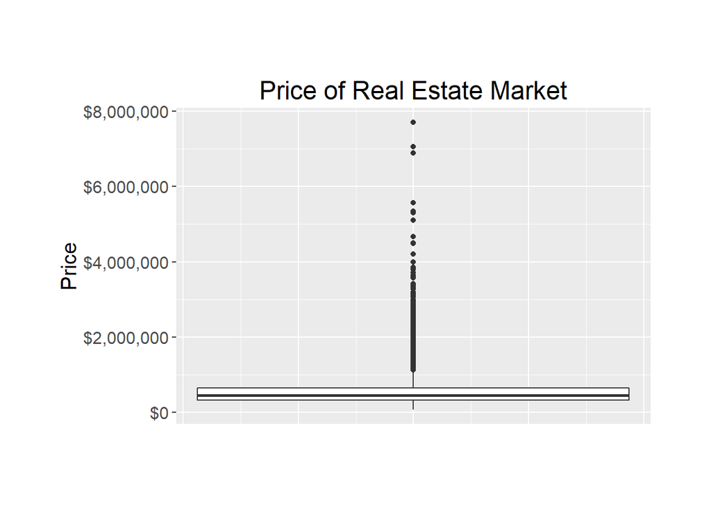

```r
ggplot(data = df) +
  geom_boxplot(mapping = aes(x = 1,y = price))+
  ggtitle('Price of Real Estate Market')+
  labs(x = '', y = 'Price')+
  scale_y_continuous(labels = scales::dollar)+
  theme(axis.title.x=element_blank(),
        axis.text.x=element_blank(),
        axis.ticks.x=element_blank(),#delete the x axis lables
        plot.title = element_text(hjust = 0.5),# title center
        text =  element_text(size=15),plot.margin = margin(2,1.5,2,1.5, "cm"))
```

We can see from the graph, there are many outliers. So we can tell there are some properties whose prices are much higher than the average of the market in our samples. The question is what causes these properties’ price so high.

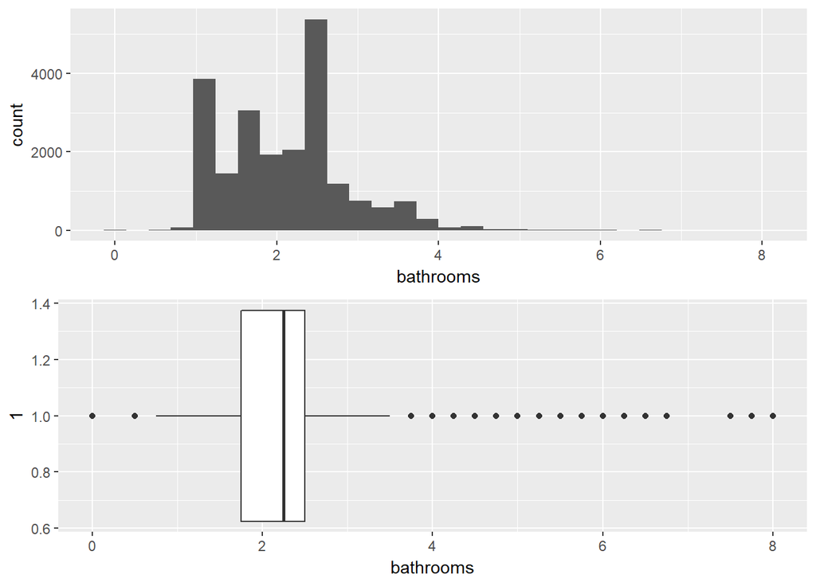

```r
grid.arrange(
# Create histogram
ggplot(data = df, mapping = aes(x = bathrooms)) +
    geom_histogram(),

# Add boxplot
ggplot(data = df, mapping = aes(x = 1)) +
    geom_boxplot(mapping = aes(y = bathrooms)) +
    coord_flip(), # use to have same x-axis on both graphs

# Set number of columns in grid.arrange
ncol = 1 )
```

Confirm that it is a skewed distribution: -We have to use median rather than mean -bathrooms above 3.5 are outliers, important to research further

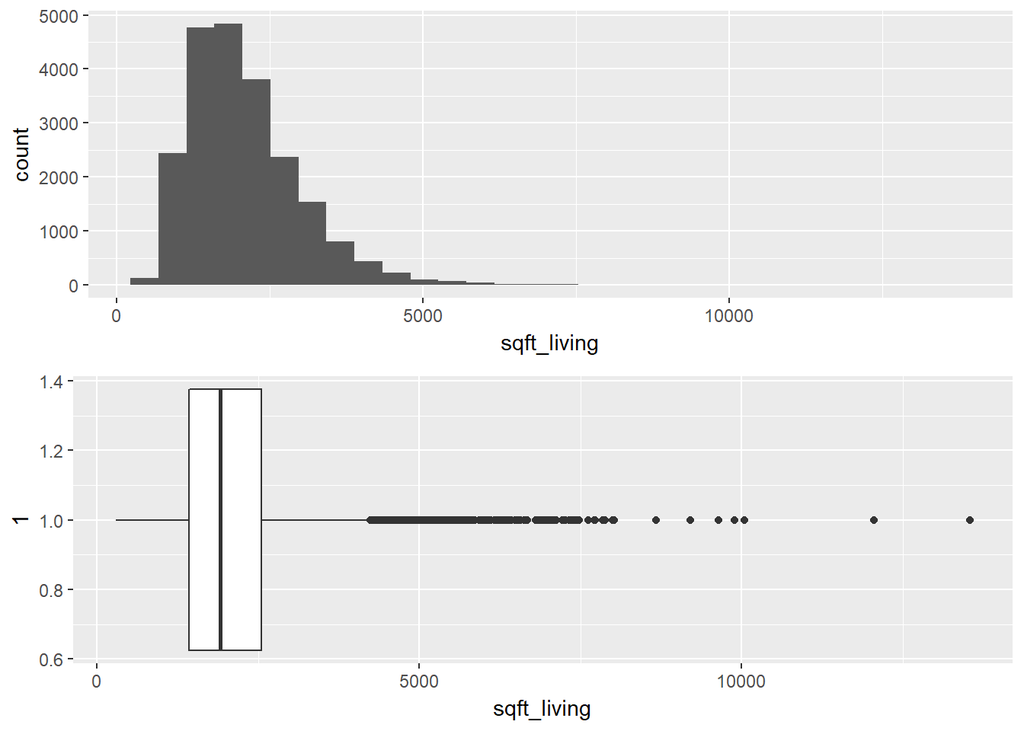

```r
grid.arrange(
# Create histogram
ggplot(data = df, mapping = aes(x = sqft_living)) +
    geom_histogram(),

# Add boxplot
ggplot(data = df, mapping = aes(x = 1)) +
    geom_boxplot(mapping = aes(y = sqft_living)) +
    coord_flip(), # use to have same x-axis on both graphs

# Set number of columns in grid.arrange
ncol = 1 )
```

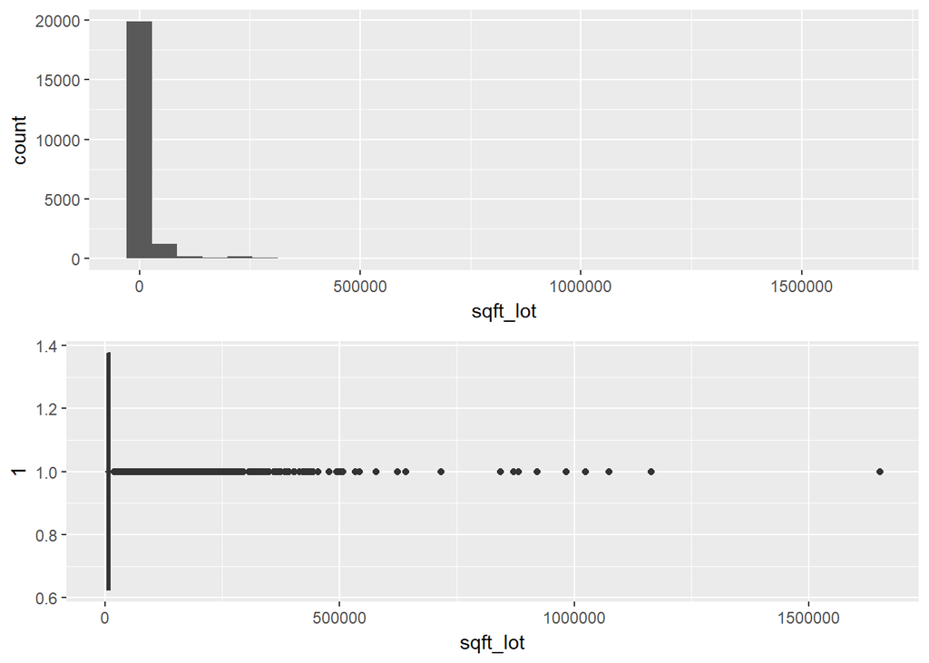

```r
grid.arrange(
# Create histogram
ggplot(data = df, mapping = aes(x = sqft_lot)) +
    geom_histogram(),

# Add boxplot
ggplot(data = df, mapping = aes(x = 1)) +
    geom_boxplot(mapping = aes(y = sqft_lot)) +
    coord_flip(), # use to have same x-axis on both graphs

# Set number of columns in grid.arrange
ncol = 1 )
```

The distribution of variables in sqft_lot varies alot The spread between all the point for sqft_lot is too big to have a graphical presentation This variable might not give us much valuable information because of the randomness nature

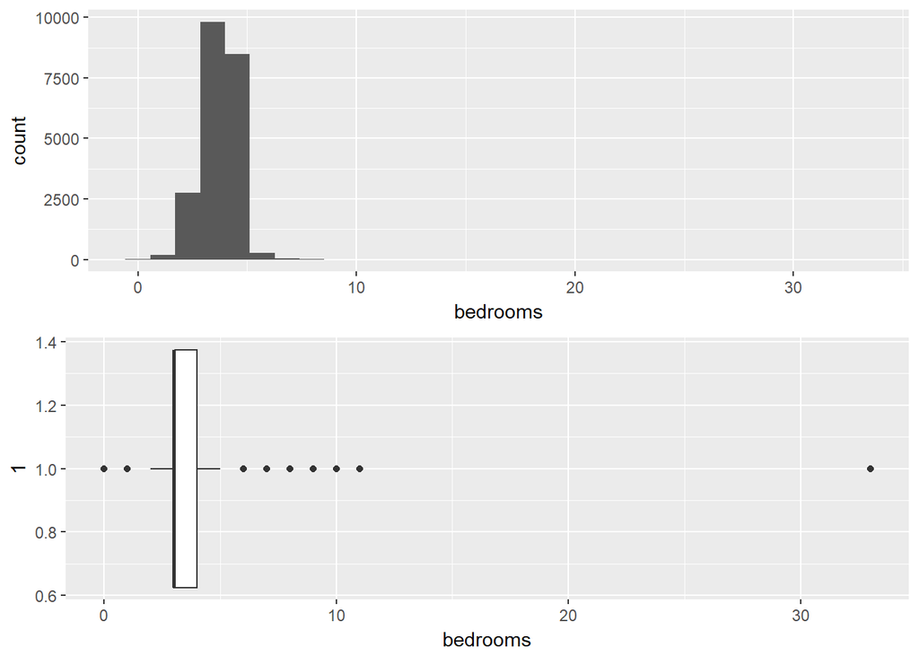

```r
grid.arrange(
# Create histogram
ggplot(data = df, mapping = aes(x = bedrooms)) +
    geom_histogram(),

# Add boxplot
ggplot(data = df, mapping = aes(x = 1)) +
    geom_boxplot(mapping = aes(y = bedrooms)) +
    coord_flip(), # use to have same x-axis on both graphs

# Set number of columns in grid.arrange
ncol = 1 )
```

Confirm the skewness of bedrooms: -We will use median instead of mean. -There are outliers above 5 bedrooms and below 2

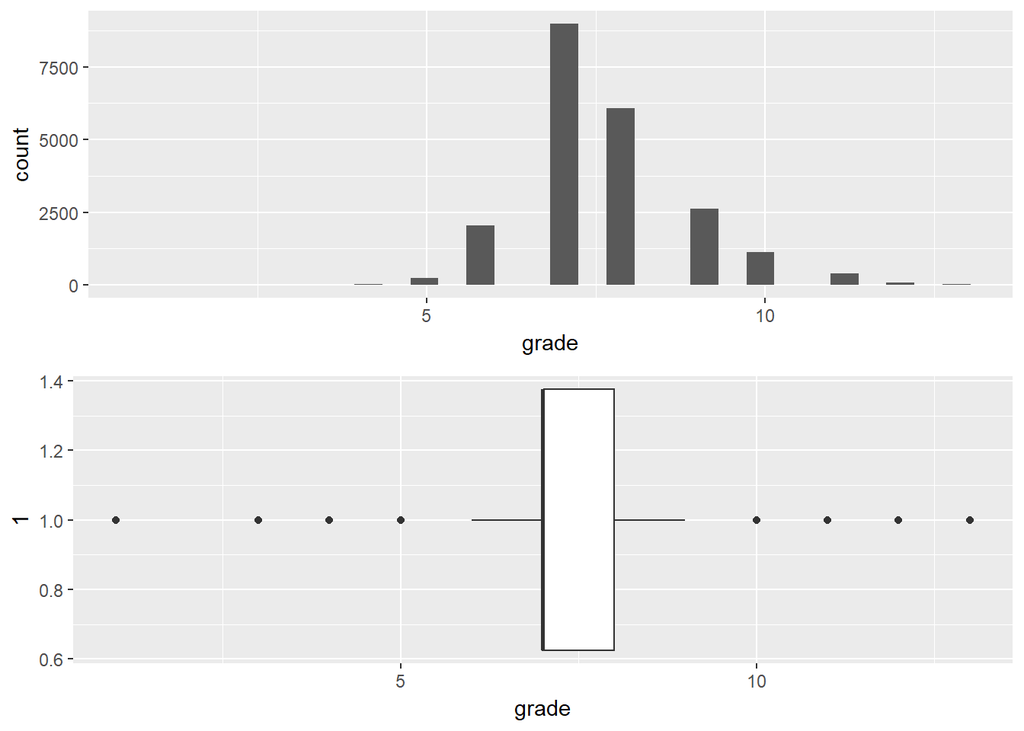

```r
grid.arrange(
# Create histogram
ggplot(data = df, mapping = aes(x = grade)) +
    geom_histogram(),

# Add boxplot
ggplot(data = df, mapping = aes(x = 1)) +
    geom_boxplot(mapping = aes(y = grade)) +
    coord_flip(), # use to have same x-axis on both graphs

# Set number of columns in grid.arrange
ncol = 1 )
```

Confirms the skewness of grade -There are outlier below 5 and above 10

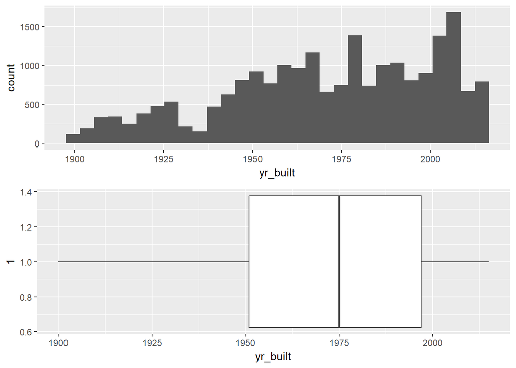

```r
grid.arrange(
# Create histogram
ggplot(data = df, mapping = aes(x = yr_built)) +
    geom_histogram(),

# Add boxplot
ggplot(data = df, mapping = aes(x = 1)) +
    geom_boxplot(mapping = aes(y = yr_built)) +
    coord_flip(), # use to have same x-axis on both graphs

# Set number of columns in grid.arrange
ncol = 1 )
```

## 4.2 Categorical variables: View and Waterfront

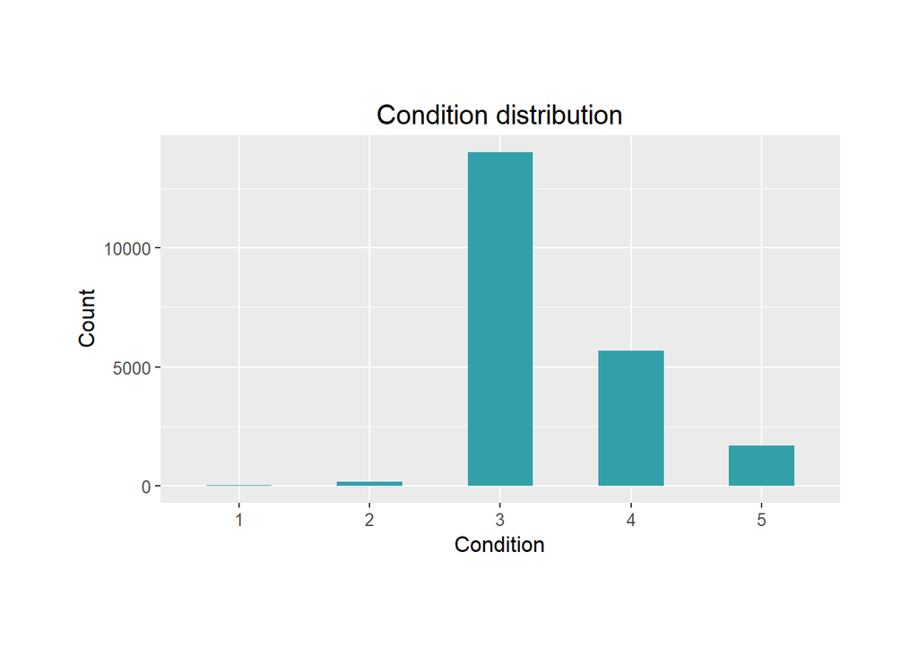

```r
ggplot(data = df, mapping = aes(x = condition ))+
  geom_bar(width=0.5,fill = '#32a0a8')+
  ggtitle('Condition distribution')+
  labs(x = 'Condition', y = 'Count')+
  theme(plot.title = element_text(hjust = 0.5,size= 15),text = element_text(size= 12),plot.margin = margin(2,1.5,2,1.5, "cm"))-> view_graph
view_graph #show the graph
```

We see that condtion 3 is most prefered.

Graph of view

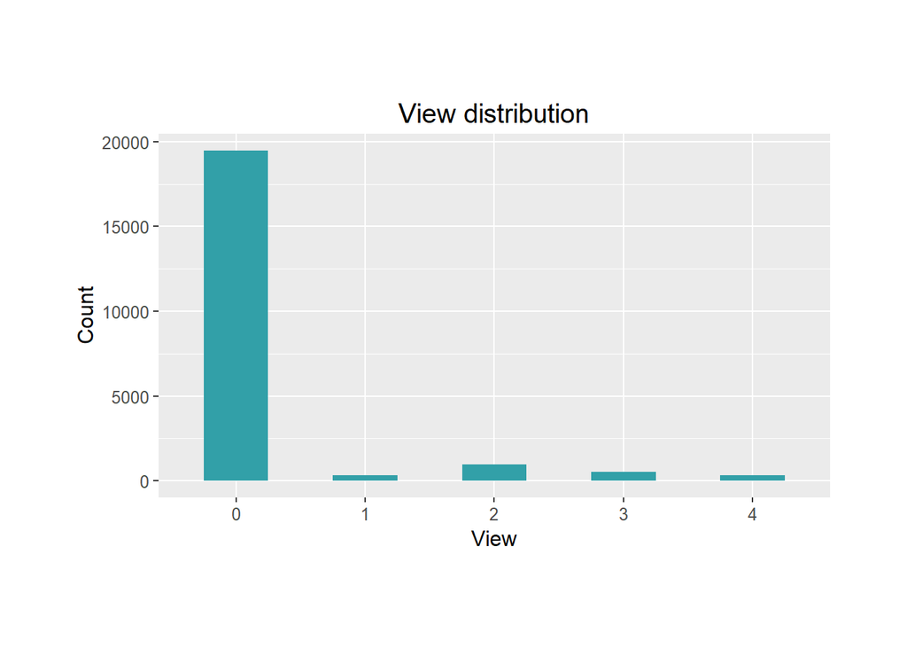

```r
ggplot(data = df, mapping = aes(x = view ))+
  geom_bar(width=0.5,fill = '#32a0a8')+
  ggtitle('View distribution')+
  labs(x = 'View', y = 'Count')+
  theme(plot.title = element_text(hjust = 0.5,size= 15),text = element_text(size= 12),plot.margin = margin(2,1.5,2,1.5, "cm"))-> view_graph
view_graph #show the graph
```

Graph of waterfront

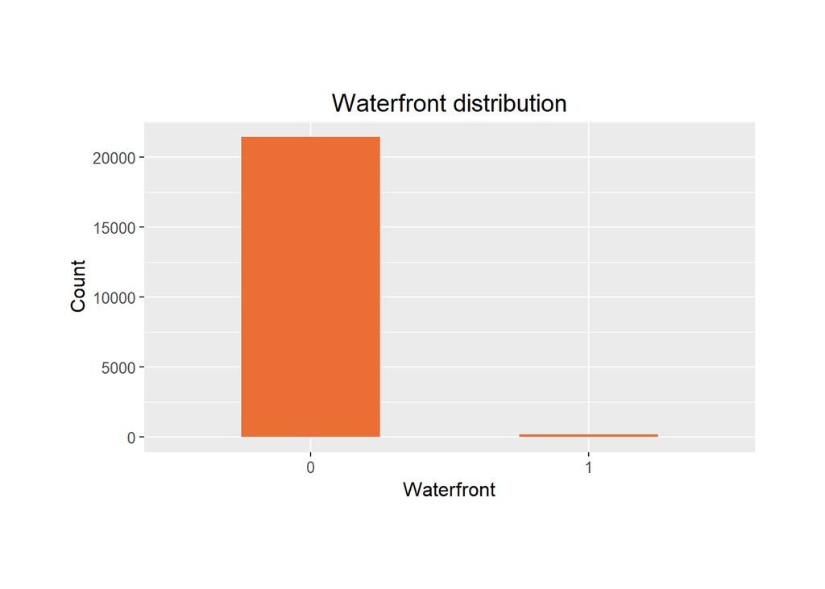

```r
ggplot(data = df, mapping = aes(x = waterfront ))+
  geom_bar(width=0.5,fill = '#eb6e34')+
  ggtitle('Waterfront distribution')+
  labs(x = 'Waterfront', y = 'Count')+
  theme(plot.title = element_text(hjust = 0.5,size= 15),text = element_text(size= 12),plot.margin = margin(2,1.5,2,1.5, "cm"))-> waterfront_graph
waterfront_graph #show the graph
```

From this graph, we can see most of the properties don’t have a good view or waterfront, considering the price graph, thes factors may be an important factors for the price, next we will try to prove this hypothesis and what else factors may be included.

# 5 Base EDA Step 3: Multivariate non-graphical

## 5.1 Categorical

We will use a three way contingency table to check the grade and condition with each waterfront and view

```r
df %>%
  tabyl(grade, condition, waterfront) %>%
  adorn_totals(where = c("row", "col"))
```

```
## $`0`
##  grade  1   2     3    4    5 Total
##      1  1   0     0    0    0     1
##      3  0   1     1    0    1     3
##      4  1   5    13   10    0    29
##      5  8  15    99   83   33   238
##      6 11  59  1032  679  245  2026
##      7  6  75  5220 2826  831  8958
##      8  2  13  4249 1379  385  6028
##      9  0   2  2027  438  123  2590
##     10  0   1   904  151   50  1106
##     11  0   0   318   51   10   379
##     12  0   0    66   10    3    79
##     13  0   0    11    2    0    13
##  Total 29 171 13940 5629 1681 21450
```

[output cut: 16 more lines]

Comments: Count pattern is not consistent with waterfront.People grade higher with houses without waterfront and better conditions.

```r
df %>%
  tabyl(grade, condition, view) %>%
  adorn_totals(where = c("row", "col"))
```

```
## $`0`
##  grade  1   2     3    4    5 Total
##      1  1   0     0    0    0     1
##      3  0   1     1    0    1     3
##      4  1   5    11    9    0    26
##      5  7  15    95   81   31   229
##      6 10  58  1008  649  230  1955
##      7  6  72  5019 2673  786  8556
##      8  2  12  3900 1183  315  5412
##      9  0   2  1752  321   85  2160
##     10  0   1   731  103   22   857
##     11  0   0   209   31    2   242
##     12  0   0    37    4    2    43
##     13  0   0     5    0    0     5
##  Total 27 166 12768 5054 1474 19489
```

[output cut: 64 more lines]

## 5.2 Quantitative

```r
df %>%
  select_if(is.numeric) %>% # Use to select just the numeric variables
  cor() %>%
  round(2) %>%
  kable()
```

|  | price | bedrooms | bathrooms | sqft_living | sqft_lot | floors | grade | yr_built |
| --- | --- | --- | --- | --- | --- | --- | --- | --- |
| price | 1.00 | 0.31 | 0.53 | 0.70 | 0.09 | 0.26 | 0.67 | 0.05 |
| bedrooms | 0.31 | 1.00 | 0.52 | 0.58 | 0.03 | 0.18 | 0.36 | 0.15 |
| bathrooms | 0.53 | 0.52 | 1.00 | 0.75 | 0.09 | 0.50 | 0.66 | 0.51 |
| sqft_living | 0.70 | 0.58 | 0.75 | 1.00 | 0.17 | 0.35 | 0.76 | 0.32 |
| sqft_lot | 0.09 | 0.03 | 0.09 | 0.17 | 1.00 | -0.01 | 0.11 | 0.05 |
| floors | 0.26 | 0.18 | 0.50 | 0.35 | -0.01 | 1.00 | 0.46 | 0.49 |
| grade | 0.67 | 0.36 | 0.66 | 0.76 | 0.11 | 0.46 | 1.00 | 0.45 |
| yr_built | 0.05 | 0.15 | 0.51 | 0.32 | 0.05 | 0.49 | 0.45 | 1.00 |

Coments: Large positive correlation between 1. price and sqft_living 2. price and grade 3.bathrooms and sqft_living 4.grade and bathrooms 5.bathrooms and sqft_living 6.grade and sqft_living sqft_lot doesn’t seem to show any strong correaltion with any variable, probably because of its random nature. -Intutively seems like price, sqft_living, bathrooms and grade are positively related among themselves. Question: Why is condition not positively correlated with sqft_living,bathrooms,grading?

# 6 Base EDA Step 4: Multi-variate graphical analysis

## 6.1 Categorical

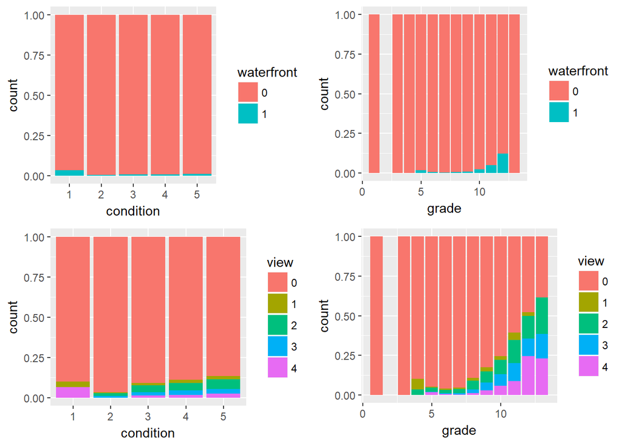

```r
grid.arrange(

  df %>%
    ggplot(mapping = aes(x = condition, fill = waterfront)) + # Add additional variable by specify "fill"
    geom_bar(position = "fill"),

  df %>%
    ggplot(mapping = aes(x = grade, fill = waterfront)) +
    geom_bar(position = "fill"),

   df %>%
    ggplot(mapping = aes(x = condition, fill = view)) + # Add additional variable by specify "fill"
    geom_bar(position = "fill"),

  df %>%
    ggplot(mapping = aes(x = grade, fill = view)) +
    geom_bar(position = "fill"),

  ncol = 2
)
```

Comment and Questions: -Higher grades have higher views, but condtions were not higher with better views.In fact, better views had worse condtions. Why is that? -Houses with better grade have more counts of waterfront but better condtions of houses did not include waterfront.

Look more closely into conditions with views:

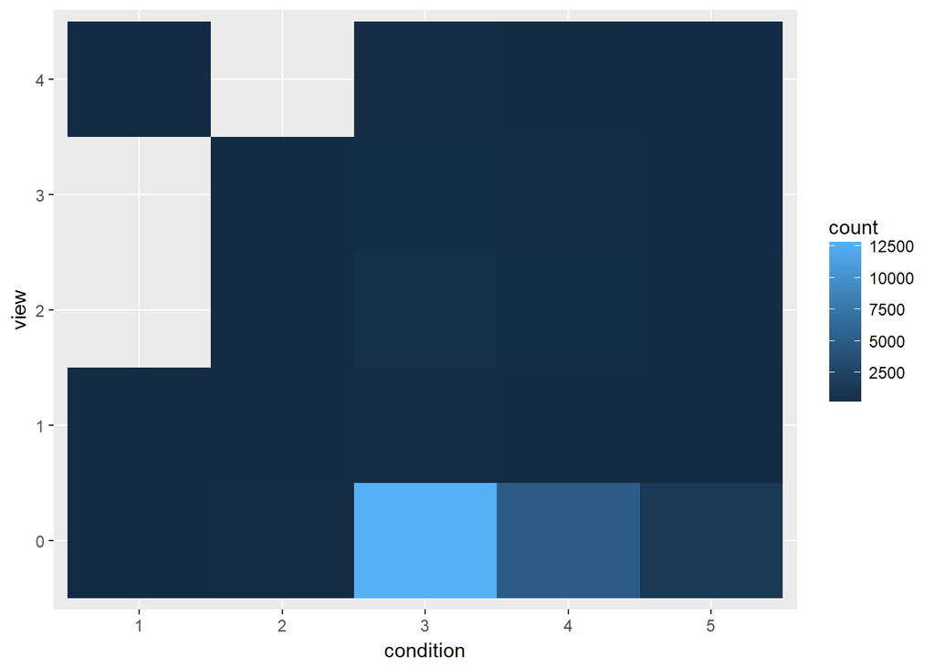

```r
df %>%
  group_by(condition, view) %>%
  summarise(count = n()) %>%
  ggplot(aes(condition, view)) +
  geom_tile(aes(fill = count))
```

Comments: People prefer to buy houses with no view if the condition is at least 3. Questions: Maybe the city area is very polluted so people do not want to buy houses with views.

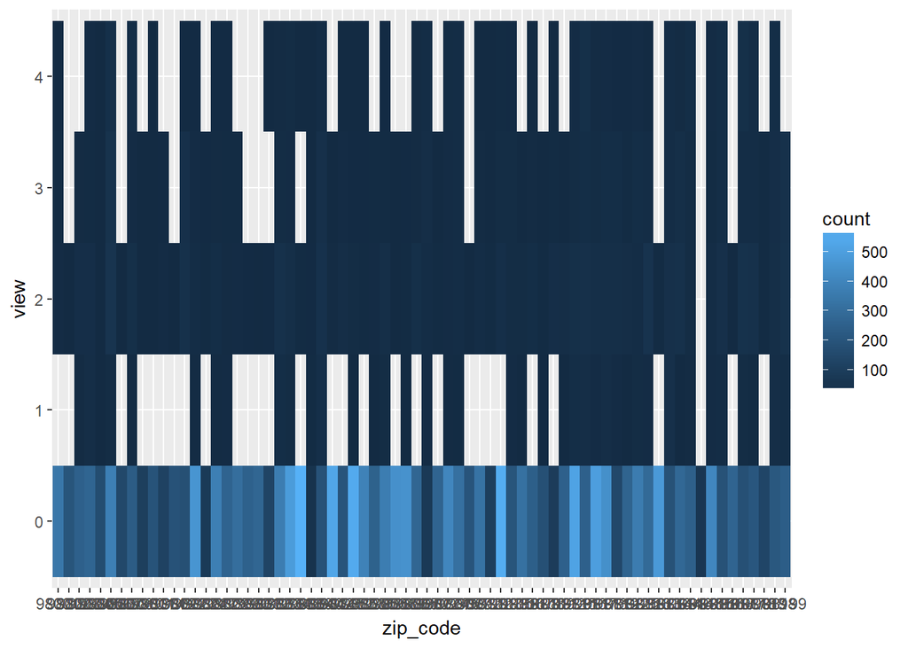

```r
df %>%
  group_by(zip_code, view) %>%
  summarise(count = n()) %>%
  ggplot(aes(zip_code, view)) +
  geom_tile(aes(fill = count))
```

Throughout all zipcodes people do not prefer view. Comment: City must have a pollution problem.

## 6.2 Quantitative

Price vs yr_built

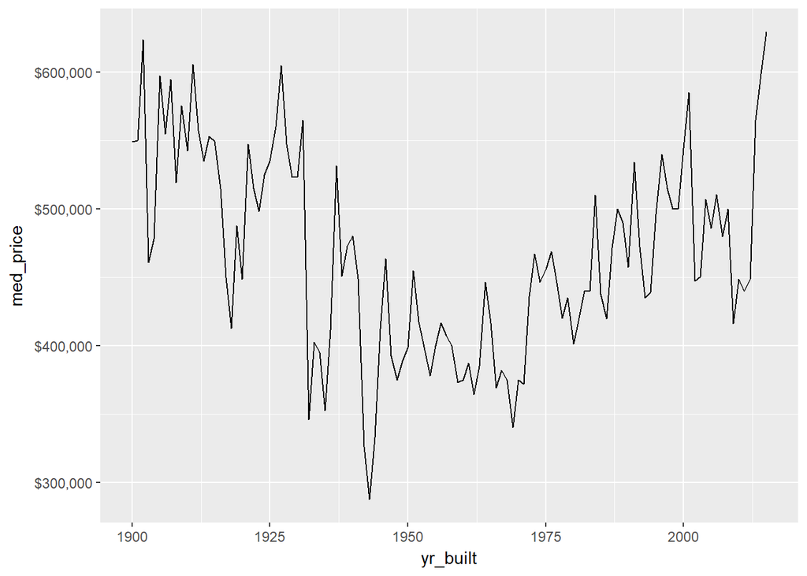

```r
grid.arrange(
df %>%
  group_by(yr_built) %>%
  summarize(med_price = median(price)) %>%
  ggplot(mapping = aes(x = yr_built, y = med_price)) +
  geom_line()+
  scale_y_continuous(labels=scales::dollar))
```

Comment: -Would to investigate why the price drops before the 1950s and then picks up again after 1975 Question: maybe renovation increased the prices?

To see the drop in median price after 1950s

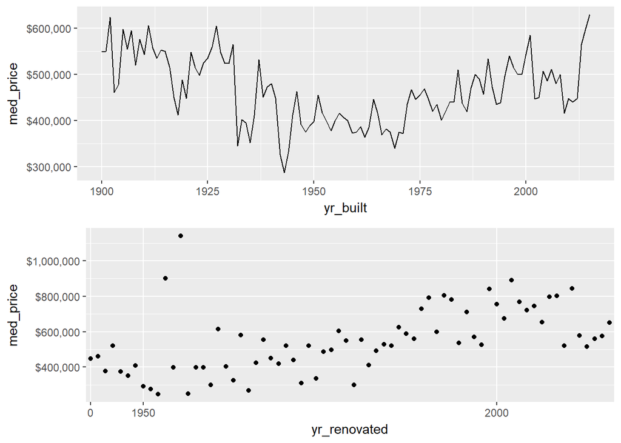

```r
medprice_yrbuilt_yrreno<-grid.arrange(
df %>%
  group_by(yr_built) %>%
  summarize(med_price = median(price)) %>%
  ggplot(mapping = aes(x = yr_built, y = med_price)) +
  geom_line()+
  scale_y_continuous(labels=scales::dollar),
df %>%
  group_by(yr_renovated)%>%
  summarise(med_price = median(price)) %>%
  ggplot(aes(x=yr_renovated,y=med_price))+
  geom_point()+
  scale_x_discrete(breaks=c(0,1950,2000))+
  scale_y_continuous(labels=scales::dollar)
)
```

```r
ggsave(filename = "medprice_yrbuilt_yrreno.png", plot = medprice_yrbuilt_yrreno)
```

A little before the 1950s,the median price for renovated houses were less than houses built, this might have cause the drop from 1940 to 1950 in median price for houses built as people prefered to get a renovated house rather than buy a new one.After the 1975, it has become more expensive to buy a renovated house rather than buy a new house.

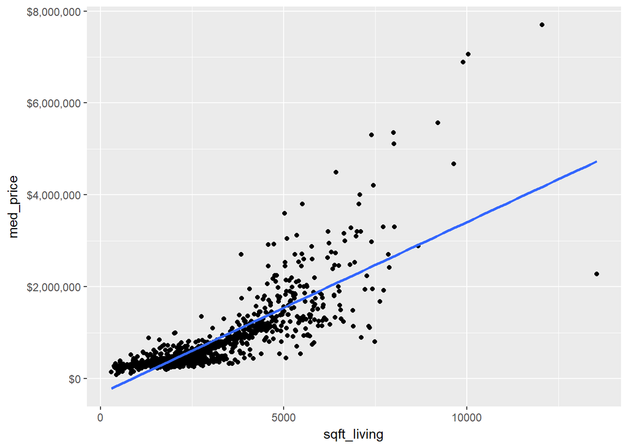

```r
price_sqft_scatter<-df %>%
  group_by(sqft_living) %>%
  summarize(med_price = median(price)) %>%
  ggplot(mapping = aes(x = sqft_living, y = med_price)) +
  geom_point()+
  geom_smooth(method ="lm", se= FALSE)+
  scale_y_continuous(labels=scales::dollar)

price_sqft_scatter
```

```r
ggsave(filename = "price_sqft.png", plot = price_sqft_scatter)
```

Consistent with out correlation coefficient interpretation.

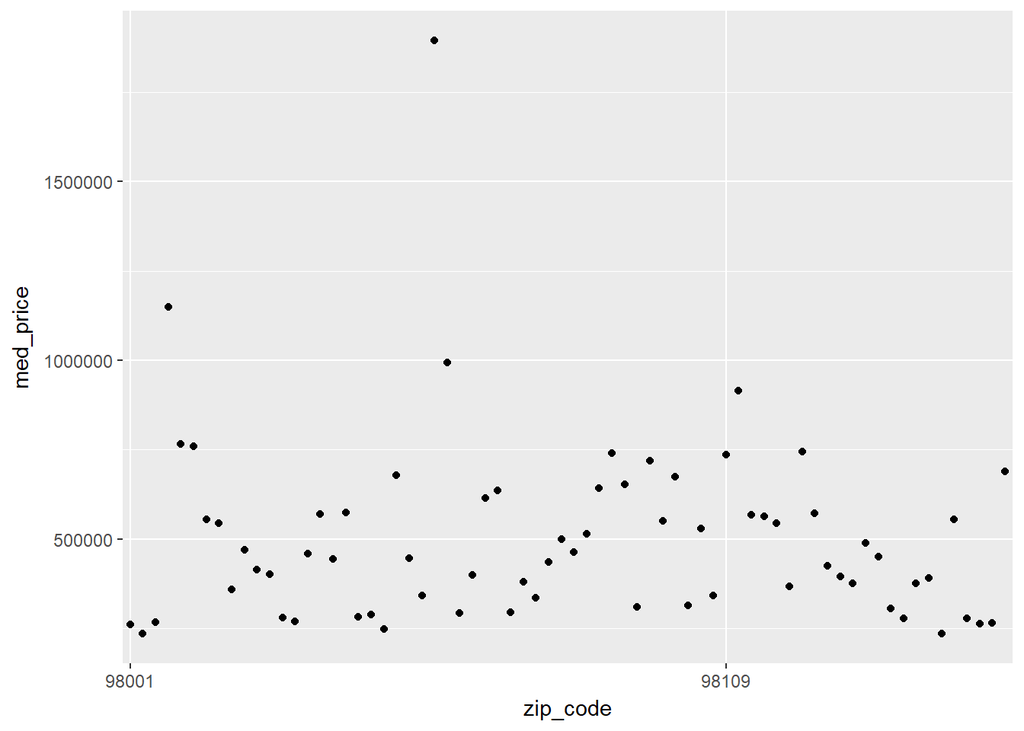

```r
df %>%
  group_by(zip_code) %>%
  summarize(med_price = median(price)) %>%
  ggplot(mapping = aes(x = zip_code, y = med_price)) +
  geom_point()+
  scale_x_discrete(breaks=c(98001,98109,98200))
```

There is no specific pattern for zipcode and med price.

## 6.3 Categorical and quantitative

Price vs condition

```
## geom_path: Each group consists of only one observation. Do you need to
## adjust the group aesthetic?
```

[figure not shown]

```r
df %>%
  group_by(condition) %>%
  summarize(med_price = median(price)) %>%
  ggplot(mapping = aes(x = condition, y = med_price)) +
  geom_line()+
  scale_y_continuous(labels=scales::dollar)
```

Question: Why is there a drop in median price from condition 3 to 4? Price vs view

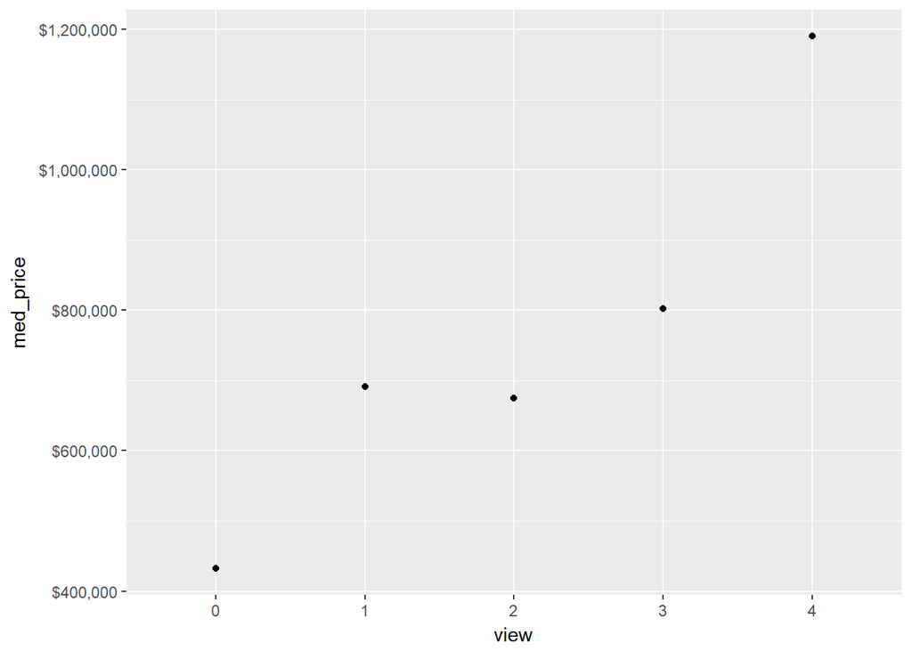

```r
df %>%
  group_by(view) %>%
  summarize(med_price = median(price)) %>%
  ggplot(mapping = aes(x = view, y = med_price)) +
  geom_point()+
  scale_y_continuous(labels=scales::dollar)
```

Question: Why is there a drop in median price from view 1 to 2?

To investigate why there was a drop in median price from condition 3 to 4 and view 1 to 2, we decide to see if grid tile will give us an explanation

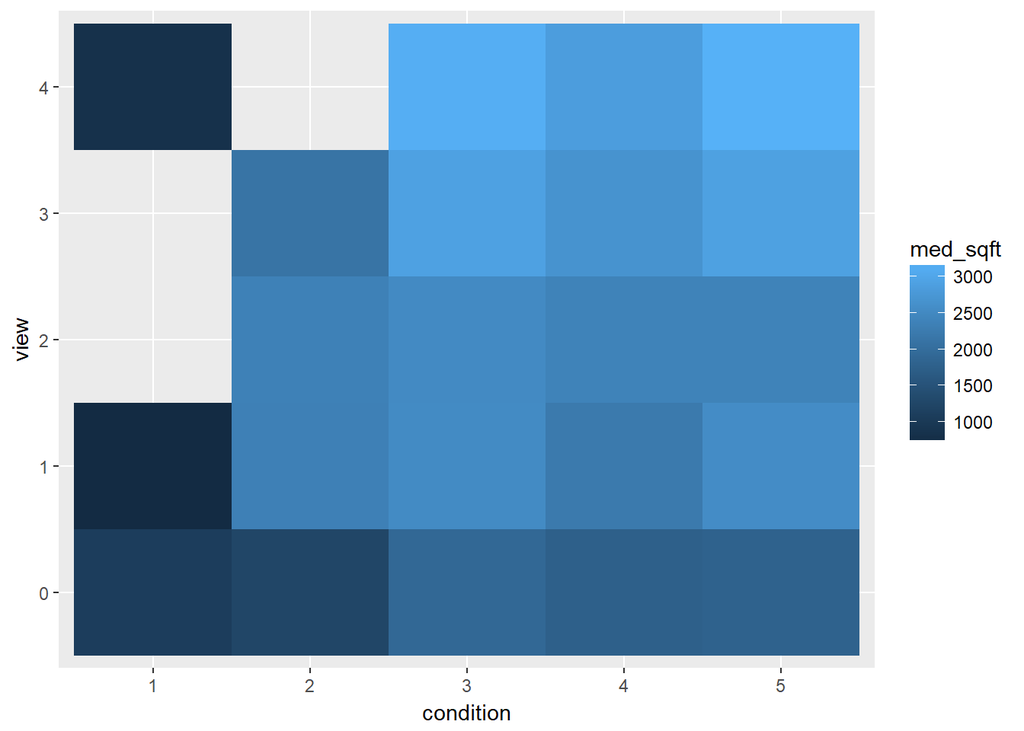

```r
df %>%
group_by(condition, view) %>%
  summarise(med_sqft = median(sqft_living)) %>%
  ggplot(aes(condition, view)) +
  geom_tile(aes(fill = med_sqft))
```

We can see that the median sqft for the grid (4,2) falls around 2000 sqft, so there is less median sqft available for those houses so the median prices drop. No further questions.

We want to investigate the quantitative and categorical variables which seem to be off interest:

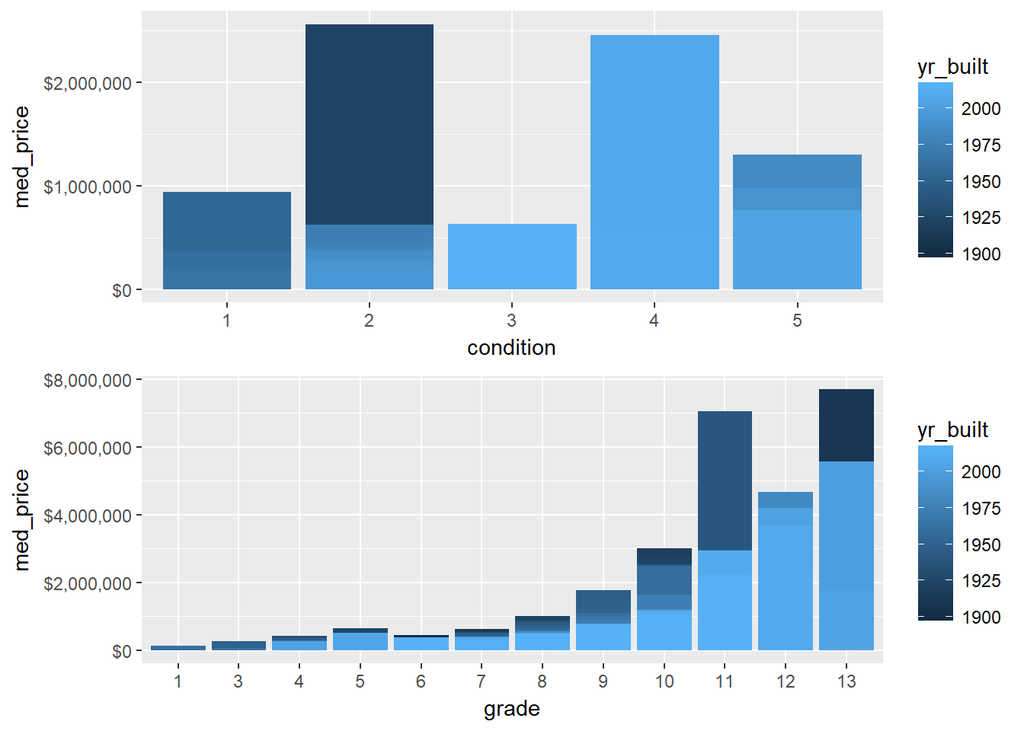

```r
yr_cond_grade<-grid.arrange(
df %>%
  group_by(condition, yr_built) %>%
  summarise(med_price = median(price)) %>%
  ggplot(mapping = aes(x = as.factor(condition), y = med_price, fill = yr_built)) + geom_bar(stat = "identity", position = "dodge") +
  labs(x = 'condition', y = 'med_price', fill="yr_built")+
  scale_y_continuous(labels=scales::dollar),

df %>%
  group_by(grade, yr_built) %>%
  summarise(med_price = median(price)) %>%
  ggplot(mapping = aes(x = as.factor(grade), y = med_price, fill = yr_built)) + geom_bar(stat = "identity", position = "dodge") +
  labs(x = 'grade', y = 'med_price', fill="yr_built")+
  scale_y_continuous(labels=scales::dollar)

)
```

```r
ggsave(filename = "yr_cond_grade.png", plot = yr_cond_grade)
```

most of the condition 2 houses were built in 1900s with a median price of over 2 million. But year 2000 + have condtion 3,4 houses with median price for condition 3 houses below a million but condition 4 houses have median prive of above 2 million. Condition 5 houses have lower median price than condition 4 because they were built <2000. …Better the grade, higher the median prices. Question: is grade a better predictor than condition for median prices for houses?

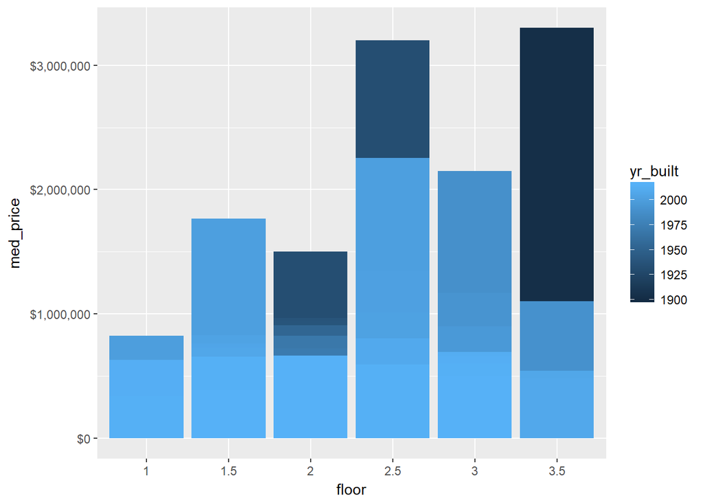

```r
df %>%
  group_by(floors,yr_built) %>%
  summarise(med_price = median(price)) %>%
  ggplot(mapping = aes(x = as.factor(floors), y = med_price, fill = yr_built)) + geom_bar(stat = "identity", position = "dodge") +
  labs(x = 'floor', y = 'med_price', fill="yr_built")+
  scale_y_continuous(labels=scales::dollar)
```

We can see that in 1900 there were more floors being built which increased the median price.As the years progress, there were less floors being which lowered the median prices.

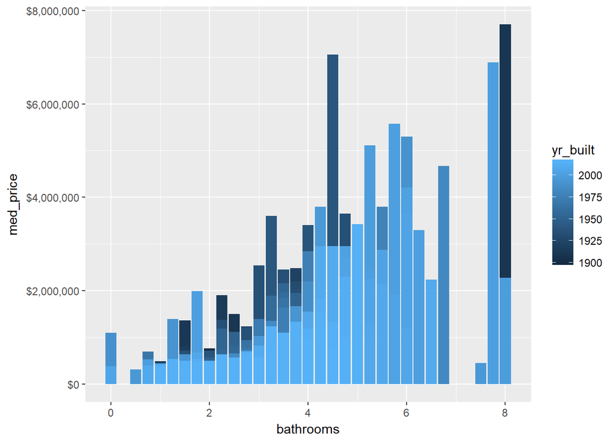

```r
df %>%
  group_by(bathrooms, yr_built) %>%
  summarise(med_price = median(price)) %>%
  ggplot(mapping = aes(x = bathrooms, y = med_price, fill = yr_built)) + geom_bar(stat = "identity", position = "dodge") +
  labs(x = 'bathrooms', y = 'med_price', fill="yr_built")+
  scale_y_continuous(labels=scales::dollar)
```

# 7 Detailed EDA: questions raised in based EDA

To answer the questions we had above:

## 7.1 Do prices differ substantially by condition or grade?

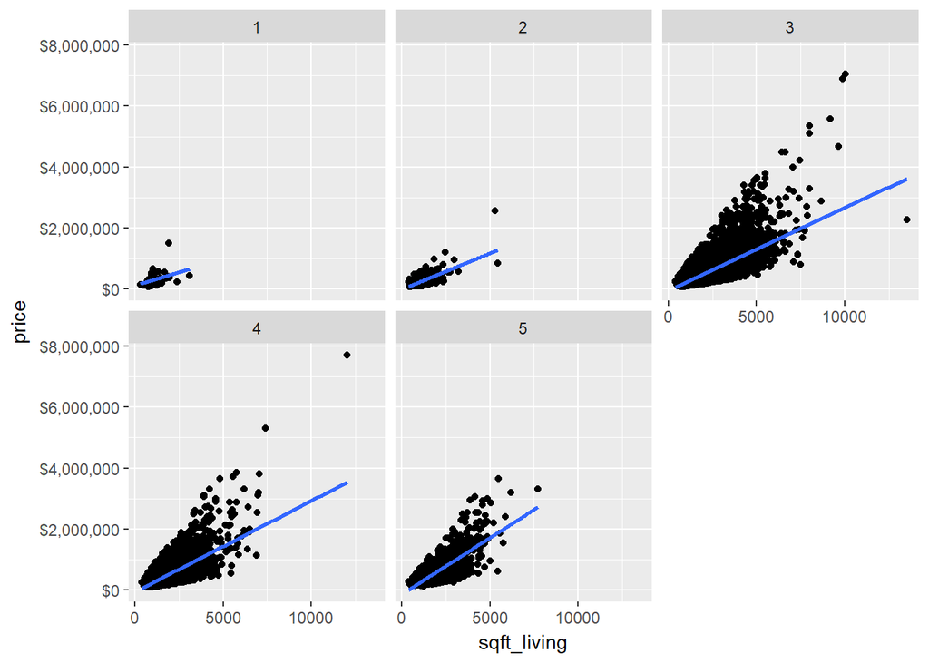

```r
con_ana <-  c("1", "2", "3", "4", "5")
grade_ana<-c("1", "3","4","5","6","7","8","9","10","11","12","13")
ln_cond<-df %>%
  filter(condition %in% con_ana) %>%
    ggplot(mapping = aes(x = sqft_living,y=price)) +
    geom_point() +
  geom_smooth(method="lm",se=FALSE)+
    facet_wrap( ~ condition)+
  scale_y_continuous(labels=scales::dollar)

ln_cond
```

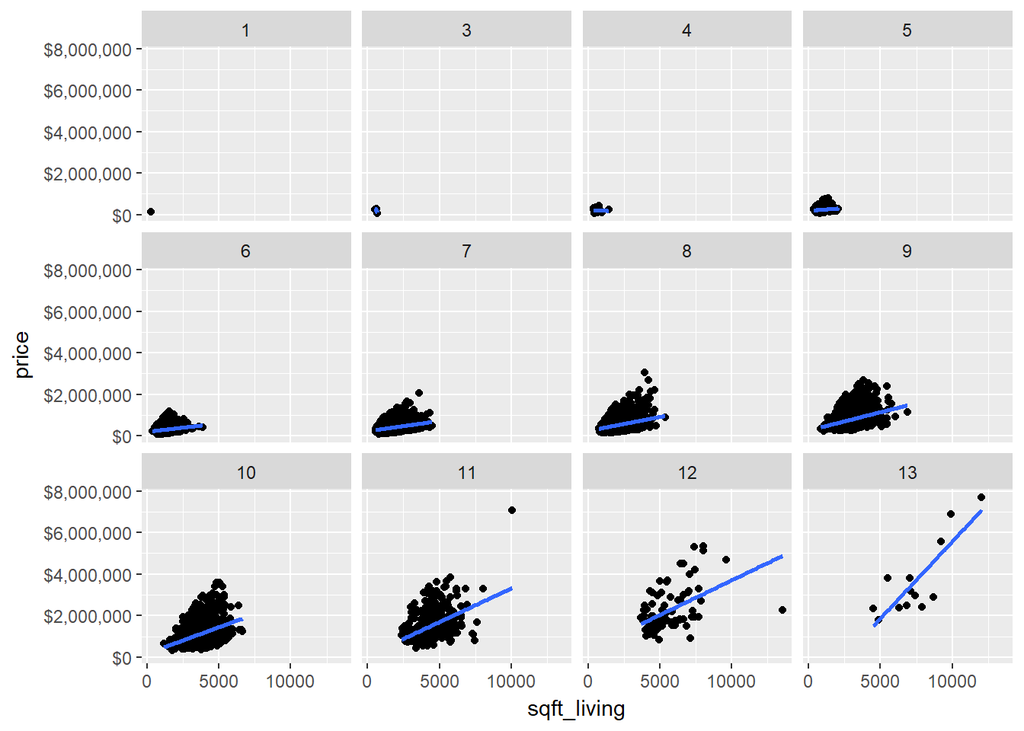

```r
ggsave(filename = "lm_Cond.png", plot = ln_cond)
lm_grade<-df %>%
  filter(grade %in% grade_ana) %>%
    ggplot(mapping = aes(x = sqft_living,y=price)) +
    geom_point() +
  geom_smooth(method="lm",se=FALSE)+
    facet_wrap( ~ grade)+
  scale_y_continuous(labels=scales::dollar)

lm_grade
```

```r
ggsave(filename = "lm_grade.png", plot = lm_grade)
```

Pattern is consistent across conditions. But pattern is not consisten across grade as we see that grade 12, 13 have different intercept and gradient.This means that condition is a more reliable indicator for price vs sqft_living.

## 7.2 Do prices differ substantially by floor or bathrooms?

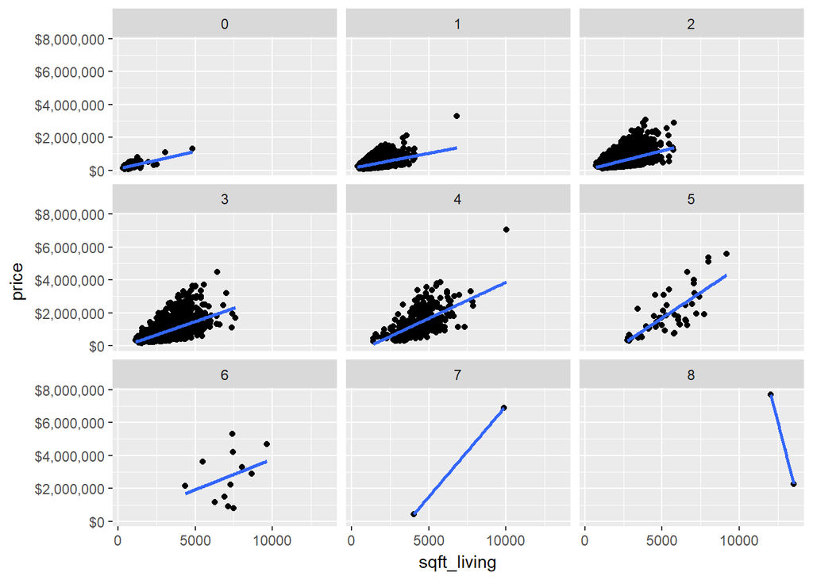

```r
df %>%
    ggplot(mapping = aes(x = sqft_living,y=price)) +
    geom_point() +
  geom_smooth(method="lm",se=FALSE)+
    facet_wrap( ~ as.integer(bathrooms))+
  scale_y_continuous(labels=scales::dollar)
```

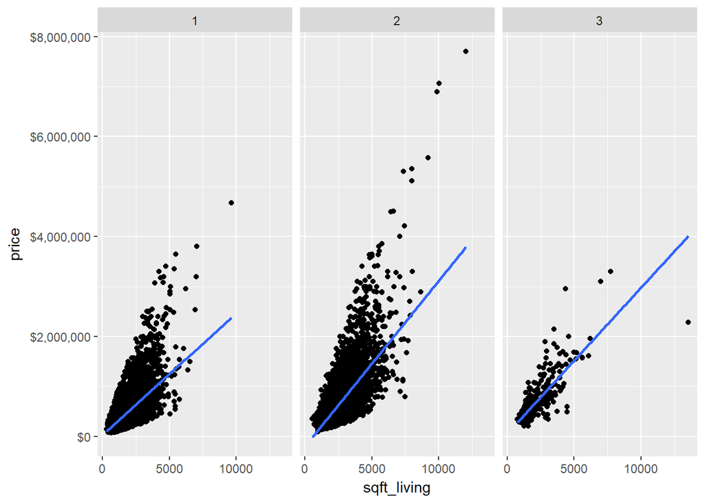

```r
df %>%
    ggplot(mapping = aes(x = sqft_living,y=price)) +
    geom_point() +
  geom_smooth(method="lm",se=FALSE)+
    facet_wrap( ~ as.integer(floors))+
  scale_y_continuous(labels=scales::dollar)
```

Floor gives us a more consistent pattern than bathroom throughout. So, Floor is a better predictor for median prices than bathroom.

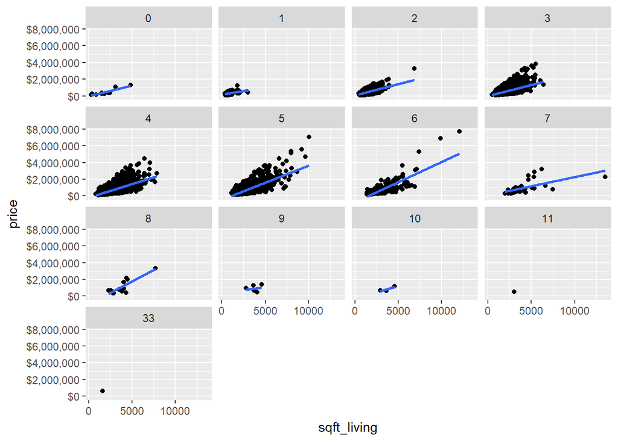

```r
df %>%
    ggplot(mapping = aes(x = sqft_living,y=price)) +
    geom_point() +
  geom_smooth(method="lm",se=FALSE)+
    facet_wrap( ~ as.integer(bedrooms))+
  scale_y_continuous(labels=scales::dollar)
```

This is to make sure that our previous assumption about weak correlation between price and bedroom holds.Floor is still a better predictor than bathroom and bedroom.

# 8 Summary

1.Floor and condition are good predictors of prices.

2.price has a positive correaltion with sqft_living

3.People prefer houses with no views at all